# Activity Projections

Steven Watson

Saturday, July 18, 2015

# Introduction

The goal of this paper is to build a model using training data to predict how “well” someone performed a particular task. The data for this project come from this source: http://groupware.les.inf.puc-rio.br/har. It is used for the Coursera Machine Learning Course Project.

# Data Gathering

We will assume the data is cut into training and testing csv files on your root directory, and we will pull it into R.

```r
set.seed(100) #setting my random seed
require(caret) #loading the caret package
```

```r
require(ggplot2) #loading the ggplot2 packages
traindata <- read.csv("~/pml-training.csv") #pulling in train data
testdata <- read.csv("~/pml-testing.csv") #pulling in test data
dim(traindata) #looking at train size
```

```
## [1] 19622   160
```

```r
dim(testdata) #looking at test size
```

```
## [1]  20 160
```

```r
unique(traindata$classe) #looking at class types
```

```
## [1] A B C D E
## Levels: A B C D E
```

# Data Analysis

The first thing we notice is there is a lot of data here, about 20k records and 160 variables. We are supposed to sift through all of this to make predictions on 20 records for one of 5 different classes (A,B,C,D,E). Since we have so little “test” data, we are actually going to subset the “train” data into a train set with 75% of the data and a test set with the remaining 25%. We will withhold the testing data as a validation set. (Note, I’ve commented a few lines of analysis out for brevity.)

```r
inTrain<-createDataPartition(y=traindata$classe,p=0.75,list=FALSE)
training <- traindata[ inTrain,]
testing <- traindata[-inTrain,]
validating <- testdata
dim(training) #looking at train size
```

```
## [1] 14718   160
```

```r
dim(testing) #looking at test size
```

```
## [1] 4904  160
```

```r
dim(validating) #looking at validating size
```

```
## [1]  20 160
```

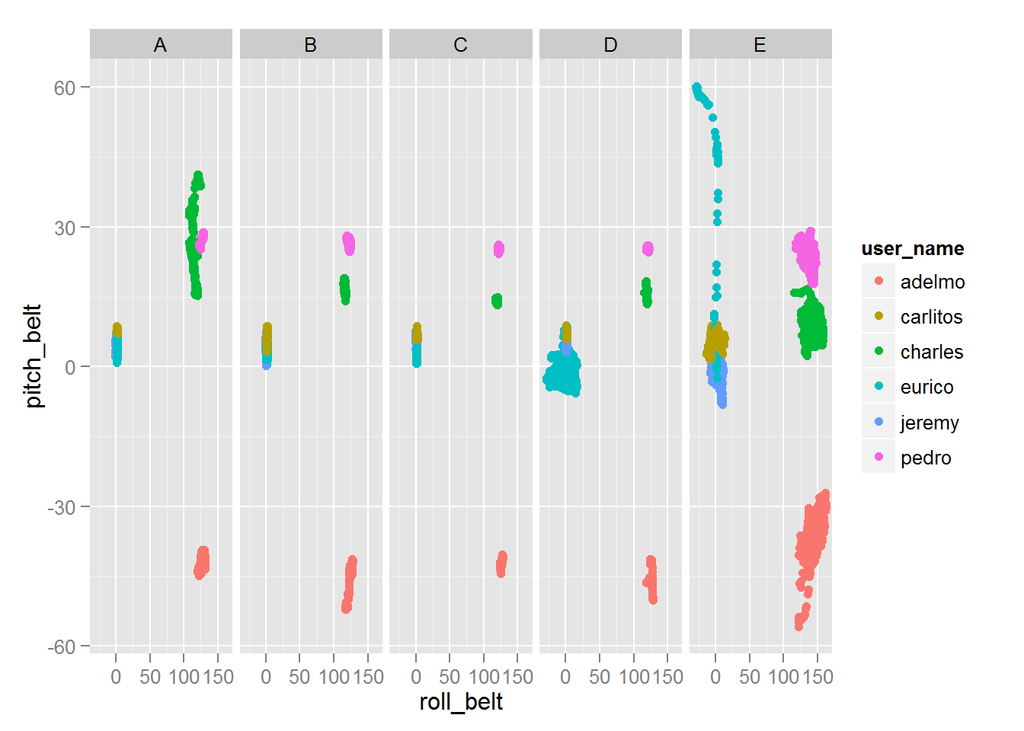

```r
#str(training$classe) #check the structure
#summary(training) #summarizing the data
qplot(roll_belt, pitch_belt,data=training, facets=.~classe, colour=user_name) #plotting data
```

# Cleaning data

Before we can start predicting anything, we should ensure our data is clean and tidy. First, we start by removing any variables that have near zero variance, as they have little impact on the model. We will also remove summary data, like min, max, var, sd, and avg using grep

```r
nvs<-nearZeroVar(training,saveMetrics=TRUE) #find the near zero var fields
training<- training[, row.names(nvs[ nvs$nzv == FALSE, ]) ] #trim for training
testing<- testing[, row.names(nvs[ nvs$nzv == FALSE, ]) ] #trim for testing
validating   <- validating[, na.omit( match(row.names(nvs[ nvs$nzv == FALSE, ]), names(validating)) )] #trim for validation

training     <- training[, -grep( "^min_|^max_|^var_|^stddev_|^amplitude_|^avg_", names(training) ) ] #trim for training
testing      <- testing[, -grep( "^min_|^max_|^var_|^stddev_|^amplitude_|^avg_", names(testing) ) ] #trim for testing
validating   <- validating[, -grep( "^min_|^max_|^var_|^stddev_|^amplitude_|^avg_", names(validating) ) ] #trim for validating
```

next we turn the user name factor variable into indicator variables

```r
usrTrain    <- dummyVars( classe ~ user_name, data = training ) #dummy var for training
training     <- cbind( predict(usrTrain, newdata=training), training ) #binding the dummy var
training     <- training[, !(names(training) == "user_name")] #removing user name

usrTest     <- dummyVars( classe ~ user_name, data = testing ) #dummy var for testing
testing      <- cbind( predict(usrTest, newdata=testing), testing ) #binding the dummy var
testing      <- testing[, !(names(testing) == "user_name")] #removing user name

usrValidate  <- dummyVars( X ~ user_name, data = validating ) #dummy var for validating
validating   <- cbind( predict(usrValidate, newdata=validating), validating ) #binding the dummy var
validating   <- validating[, !(names(validating) == "user_name")] #removing user name
```

Next we rearrange the data to make it easier to use

```r
training     <- cbind( training[, c(64, 7:11)], training[, c(1:6, 12:63)] ) #bring classe to the front
testing      <- cbind( testing[, c(64, 7:11)], testing[, c(1:6, 12:63)] ) #bring classe to the front
validating   <- cbind( validating[, c(7:11)], validating[, c(1:6, 12:63)] ) #bring classe to the front
```

Next we center and scale the non factor variables. Note that the scaling we do for the train set we must apply on all three sets

```r
stdvObj <- preProcess( training[, c(7:64)], method = c("center", "scale") ) #center and scale the train set
training     <- cbind(  training[, c(1:6)], predict( stdvObj, training[, c(7:64)] )  ) #apply to training set
testing    <- cbind(  testing[, c(1:6)], predict( stdvObj, testing[, c(7:64)] )  ) #apply to testing set
validating   <- cbind(  validating[, c(1:5)], predict( stdvObj, validating[, c(6:63)] )  ) #apply to validation set
```

Next, we impute any missing pieces of data in the non factor fields. Again, we use the train set prediction on all 3 sets.

```r
impObj <- preProcess( training[, c(7:64)], method = c("knnImpute") ) #imputing missing values
training     <- cbind(  training[, c(1:6)], predict( impObj, training[, c(7:64)] )  ) #bringing in missing values
testing      <- cbind(  testing[, c(1:6)], predict( impObj, testing[, c(7:64)] )  )
validating   <- cbind(  validating[, c(1:5)], predict( impObj, validating[, c(6:63)] )  )
```

Finally, we remove the time stamps and row numbers

```r
training     <- cbind( list( "classe" = training[, 1] ), training[, c(6:64)] ) #removing time stamps
testing    <- cbind( list( "classe" = testing[, 1] ), testing[, c(6:64)] )
validating   <- validating[, c(5:63)]
sum(is.na(training)) #checking for NAs
```

```
## [1] 0
```

# Data Modeling

We end up with a model with 60 variables (including the classe predictor) that is centered with no NAs. Let’s try our first model with a decision tree

```r
modFit<-train(classe ~., data=training, method="rpart") #run a decision tree model
modFit #view the model
```

```
## CART
##
## 14718 samples
##    59 predictor
##     5 classes: 'A', 'B', 'C', 'D', 'E'
##
## No pre-processing
## Resampling: Bootstrapped (25 reps)
##
## Summary of sample sizes: 14718, 14718, 14718, 14718, 14718, 14718, ...
##
## Resampling results across tuning parameters:
##
##   cp          Accuracy   Kappa       Accuracy SD  Kappa SD
##   0.03621950  0.5449092  0.41538815  0.02626502   0.04066091
##   0.05665527  0.4277536  0.22528235  0.06884780   0.11448946
##   0.11782018  0.3305769  0.06924518  0.04084078   0.06271971
##
## Accuracy was used to select the optimal model using  the largest value.
## The final value used for the model was cp = 0.0362195.
```

```r
modFit$finalModel #view the final model
```

```
## n= 14718
##
## node), split, n, loss, yval, (yprob)
##       * denotes terminal node
##
##  1) root 14718 10533 A (0.28 0.19 0.17 0.16 0.18)
##    2) roll_belt< 1.054559 13459  9283 A (0.31 0.21 0.19 0.18 0.11)
##      4) pitch_forearm< -1.58336 1186     9 A (0.99 0.0076 0 0 0) *
##      5) pitch_forearm>=-1.58336 12273  9274 A (0.24 0.23 0.21 0.2 0.12)
##       10) num_window>=45.5 11731  8732 A (0.26 0.24 0.22 0.2 0.087)
##         20) magnet_dumbbell_y< 0.6585148 9952  7026 A (0.29 0.19 0.25 0.19 0.082)
##           40) roll_forearm< 0.8260054 6232  3599 A (0.42 0.19 0.18 0.16 0.043) *
##           41) roll_forearm>=0.8260054 3720  2389 C (0.079 0.19 0.36 0.23 0.15) *
##         21) magnet_dumbbell_y>=0.6585148 1779   796 B (0.041 0.55 0.049 0.24 0.11) *
##       11) num_window< 45.5 542   103 E (0 0 0 0.19 0.81) *
##    3) roll_belt>=1.054559 1259     9 E (0.0071 0 0 0 0.99) *
```

```r
require(rattle) #load the rattle package
```

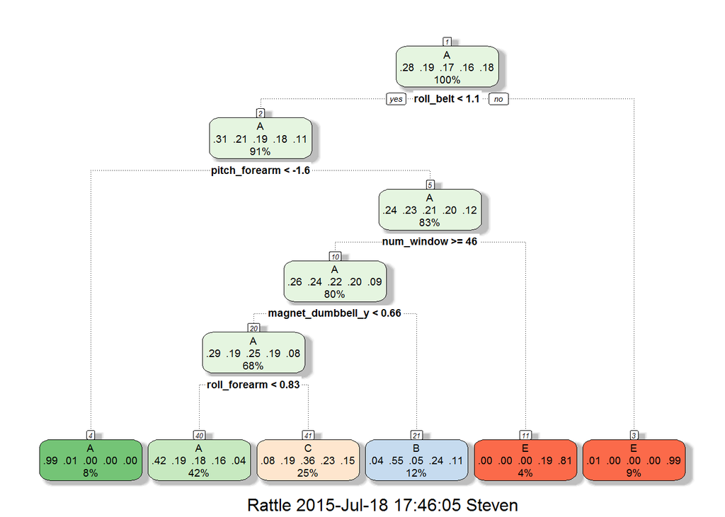

```r
fancyRpartPlot(modFit$finalModel) #plot the deicision tree
```

```r
rpartPrediction<-predict(modFit,newdata=testing) #run the model on the test set
confusionMatrix(rpartPrediction,testing$classe) #score the model
```

```
## Confusion Matrix and Statistics
##
##           Reference
## Prediction    A    B    C    D    E
##          A 1255  396  435  336  103
##          B   26  324   25  149   81
##          C  109  229  395  276  202
##          D    0    0    0    0    0
##          E    5    0    0   43  515
##
## Overall Statistics
##
##                Accuracy : 0.5075
##                  95% CI : (0.4934, 0.5216)
##     No Information Rate : 0.2845
##     P-Value [Acc > NIR] : < 2.2e-16
##
##                   Kappa : 0.3567
##  Mcnemar's Test P-Value : < 2.2e-16
##
## Statistics by Class:
##
##                      Class: A Class: B Class: C Class: D Class: E
## Sensitivity            0.8996  0.34141  0.46199   0.0000   0.5716
## Specificity            0.6381  0.92895  0.79847   1.0000   0.9880
## Pos Pred Value         0.4970  0.53554  0.32618      NaN   0.9147
## Neg Pred Value         0.9412  0.85462  0.87544   0.8361   0.9111
## Prevalence             0.2845  0.19352  0.17435   0.1639   0.1837
## Detection Rate         0.2559  0.06607  0.08055   0.0000   0.1050
## Detection Prevalence   0.5149  0.12337  0.24694   0.0000   0.1148
## Balanced Accuracy      0.7689  0.63518  0.63023   0.5000   0.7798
```

Well, better than nothing, but only 51% accurate. But we know decision trees aren’t the greatest. Let’s try something more advanced, like random forests.

```r
rfFit<-train(classe ~., data=training, method="rf",prox=TRUE, trControl = trainControl(method = "cv", number = 2))
rfFit #view the model
```

```
## Random Forest
##
## 14718 samples
##    59 predictor
##     5 classes: 'A', 'B', 'C', 'D', 'E'
##
## No pre-processing
## Resampling: Cross-Validated (2 fold)
##
## Summary of sample sizes: 7359, 7359
##
## Resampling results across tuning parameters:
##
##   mtry  Accuracy   Kappa      Accuracy SD   Kappa SD
##    2    0.9886533  0.9856454  0.0004804367  0.0006092552
##   30    0.9930018  0.9911478  0.0035552318  0.0044969074
##   59    0.9911673  0.9888265  0.0024982710  0.0031596428
##
## Accuracy was used to select the optimal model using  the largest value.
## The final value used for the model was mtry = 30.
```

```r
rfFit$finalModel #view the final model
```

```
##
## Call:
##  randomForest(x = x, y = y, mtry = param$mtry, proximity = TRUE)
##                Type of random forest: classification
##                      Number of trees: 500
## No. of variables tried at each split: 30
##
##         OOB estimate of  error rate: 0.18%
## Confusion matrix:
##      A    B    C    D    E  class.error
## A 4183    1    0    0    1 0.0004778973
## B    6 2841    1    0    0 0.0024578652
## C    0    3 2564    0    0 0.0011686794
## D    0    0    9 2402    1 0.0041459370
## E    0    1    0    4 2701 0.0018477458
```

```r
rfPrediction<-predict(rfFit,newdata=testing) #run the model on the test set
confusionMatrix(rfPrediction,testing$classe) #score the model
```

```
## Confusion Matrix and Statistics
##
##           Reference
## Prediction    A    B    C    D    E
##          A 1395    2    0    0    0
##          B    0  945    2    0    0
##          C    0    2  853    6    0
##          D    0    0    0  798    2
##          E    0    0    0    0  899
##
## Overall Statistics
##
##                Accuracy : 0.9971
##                  95% CI : (0.9952, 0.9984)
##     No Information Rate : 0.2845
##     P-Value [Acc > NIR] : < 2.2e-16
##
##                   Kappa : 0.9964
##  Mcnemar's Test P-Value : NA
##
## Statistics by Class:
##
##                      Class: A Class: B Class: C Class: D Class: E
## Sensitivity            1.0000   0.9958   0.9977   0.9925   0.9978
## Specificity            0.9994   0.9995   0.9980   0.9995   1.0000
## Pos Pred Value         0.9986   0.9979   0.9907   0.9975   1.0000
## Neg Pred Value         1.0000   0.9990   0.9995   0.9985   0.9995
## Prevalence             0.2845   0.1935   0.1743   0.1639   0.1837
## Detection Rate         0.2845   0.1927   0.1739   0.1627   0.1833
## Detection Prevalence   0.2849   0.1931   0.1756   0.1631   0.1833
## Balanced Accuracy      0.9997   0.9976   0.9978   0.9960   0.9989
```

# Cross Validation and Sample Error

It is not necesary to do any extra cross validation because the train function does this internally with the “cv” trainControl method.

# Validation Data

Finally, we need to submit the validation data. This is done externally through the coursera site, but the correct answers are given below

```r
rfValidating<-predict(rfFit,newdata=validating)
rfValidating
```

```
##  [1] B A B A A E D B A A B C B A E E A B B B
## Levels: A B C D E
```

```r
submission<-as.character(rfValidating)
```